# STATS 326/786

Week 1 Tutorial

> The National Basketball Association (NBA) is North America’s premier men’s professional basketball league. Data has been collected on 54 random NBA players. The following variables have been measured: height (in feet), weight (in pounds), fgp (field goal percentage), ftp (free-throw percentage), and ppg (average points-per-game).
> 1. Read in `basketball.csv` using `read_csv` and convert the data frame to a `tibble` object.

Solution:

```r
data <- as_tibble(read_csv("basketball.csv"))
```

> 2. Use the `mutate` function to create the following new variables in your `tibble` object: height (in m), weight (in kg), body-mass-index (BMI), and a binary indicator that determines if an NBA player is tall or short (where a player is classified as tall if they are taller than 6.5 ft).

The following conversions will help:

$$\begin{eqnarray*}
\text{height (m)} &=& \text{height (ft)} \times 0.3048 \\
\text{weight (kg)} &=& \text{weight (lb)} \times 0.45359237 \\
\text{bmi} &=& \frac{\text{weight (kg)}}{\text{height (m)}^2}
\end{eqnarray*}$$

Hint: The `ifelse` function may be useful for creating your binary indicator.

Solution:

```r
data <- data %>%
  mutate(height.m = height * 0.3048,
         weight.kg = weight * 0.45359237,
         bmi = weight.kg / height.m ^ 2,
         tallshort = ifelse(height <= 6.5, "Short", "Tall"))
```

> 3. Use the `group_by` and `summarise` functions to calculate the mean field goal percentage, free throw percentage, and points-per-game for short versus tall NBA players.

Solution:

```r
data %>%
  group_by(tallshort) %>%
  summarise(mean.fgp = mean(fgp),
            mean.ftp = mean(ftp),
            mean.ppg = mean(ppg))
```

```
## # A tibble: 2 × 4
##   tallshort mean.fgp mean.ftp mean.ppg
##   <chr>        <dbl>    <dbl>    <dbl>
## 1 Short        0.427    0.757     12.9
## 2 Tall         0.470    0.727     10.8
```

> 4. Find the largest and smallest average points-per-game for tall versus short NBA players.

```r
data %>%
  group_by(tallshort) %>%
  summarise(min.ppg = min(ppg),
            max.ppg = max(ppg))
```

```
## # A tibble: 2 × 3
##   tallshort min.ppg max.ppg
##   <chr>       <dbl>   <dbl>
## 1 Short         7.7    27.4
## 2 Tall          2.8    25
```

> 5. Use `ggplot` and `geom_point` to make a scatter plot of weight (in kg) by height (in m), and size by BMI. Use the `alpha` command to add transparency. Comment on the plot.

Solution:

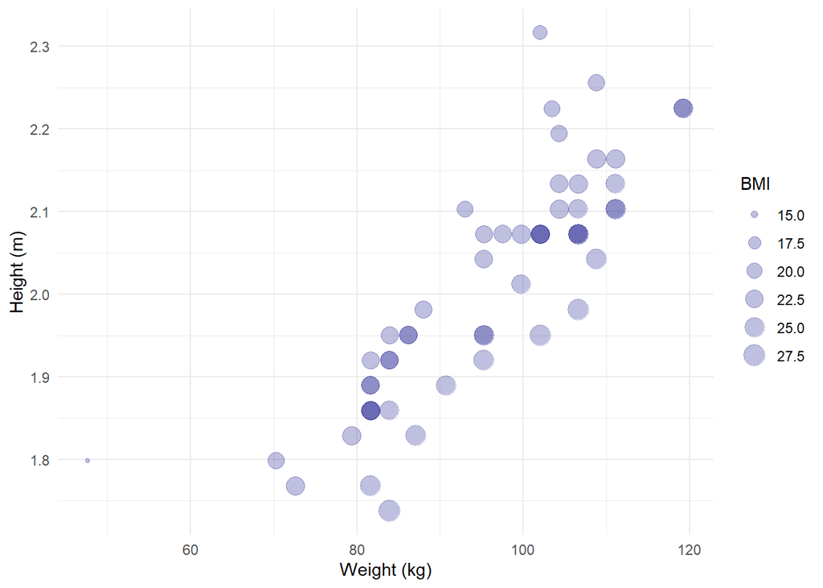

```r
ggplot(data = data,
       mapping = aes(x = weight.kg,
                     y = height.m,
                     size = bmi)) +
  geom_point(col = "navy", alpha = 0.25) +
  labs(x = "Weight (kg)",
       y = "Height (m)",
       size = "BMI") +
  theme_minimal()
```

> 6. Use `ggplot` and `geom_point` to make a scatter plot of field goal percentage by average points-per-game, with short and tall NBA players on different panels. Comment on the plot.

Solution:

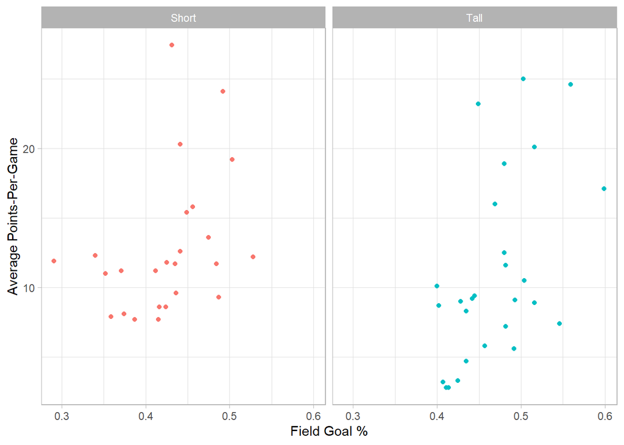

```r
ggplot(data = data,
       mapping = aes(x = fgp,
                     y = ppg,
                     col = tallshort)) +
  geom_point() +
  facet_wrap(~ tallshort) +
  labs(x = "Field Goal %",
       y = "Average Points-Per-Game") +
  theme_light() +
  theme(legend.position = "none")  # Removes the redundant legend
```

> 7. Use `ggplot` and `geom_histogram` to make a histogram of average points-per-game, colouring by your binary height indicator. Use the `alpha` command to add transparency. Comment on the plot.

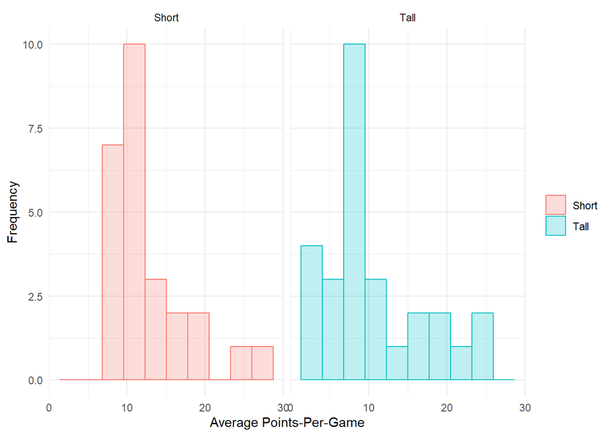

```r
ggplot(data = data,
       mapping = aes(x = ppg,
                     fill = tallshort,
                     colour = tallshort)) +
  geom_histogram(alpha = 0.25, bins = 10) +
  xlab("Average Points-Per-Game") +
  ylab("Frequency") +
  theme_minimal() +
  theme(legend.title = element_blank()) +
  facet_wrap(~ tallshort)
```

> 8. If you finish early, play around with other `geom` functions, `aes` mappings, as well as other `scale` and `theme` options.

Solution:

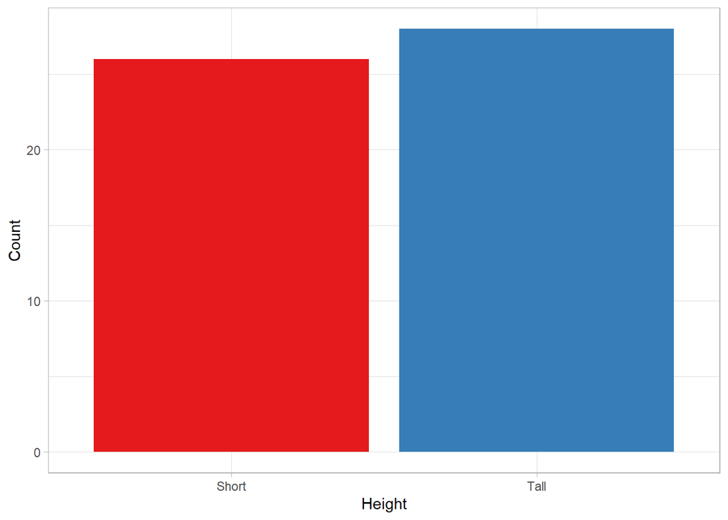

```r
# Example 1:
ggplot(data = data,
       mapping = aes(x = tallshort,
                     fill = tallshort)) +
  geom_bar() +
  scale_fill_brewer(palette = "Set1") +  # Colour palette (see help file for others)
  labs(x = "Height",
       y = "Count") +
  theme_light() +  # Light theme
  theme(legend.position = "none")  # Remove legend
```

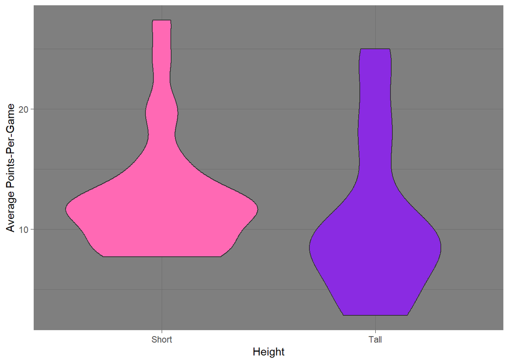

```r
# Example 2:
ggplot(data = data,
       mapping = aes(x = tallshort,
                     y = ppg,
                     fill = tallshort)) +
  geom_violin() +
  scale_fill_manual(values = c("hotpink", "blueviolet")) + # Define own colours
  labs(x = "Height",
       y = "Average Points-Per-Game") +
  theme_dark() +  # Dark theme
  theme(legend.position = "none")  # Remove legend
```

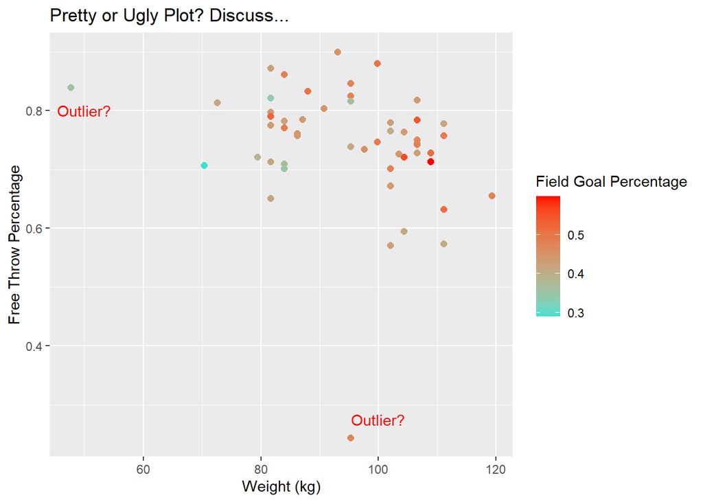

```r
# Example 3:
ggplot(data = data,
       mapping = aes(x = weight.kg,
                     y = ftp,
                     col = fgp)) +
  geom_point(size = 2) +
  scale_colour_gradient(low = "turquoise", high = "red") + # Colour gradient
  labs(title = "Pretty or Ugly Plot? Discuss...",
       x = "Weight (kg)",
       y = "Free Throw Percentage",
       col = "Field Goal Percentage") + # Labels
  annotate(geom = "text", x = c(50, 100), y = c(0.8, 0.275), label = "Outlier?",
           col = "red")
```